# Comparing Spanish Wine Regions with a Bayesian Hierarchical Model

Sam Koscelny

2025-08-20

## 1. Overview

This analysis compares critic scores across five Spanish wine regions using a **Bayesian hierarchical model** implemented via Gibbs sampling. We examine two scenarios:

- **Budget Mode**: Wines priced between $15–$20 (value comparison)
- **All Prices**: Complete dataset (overall quality comparison)

### Key Questions

1. Which Spanish wine regions consistently receive higher critic scores?
2. Does the ranking change when we restrict to budget-friendly wines?
3. How much variation in scores is attributable to region vs. individual bottles?

## 2. Data Processing

### Load and Filter Data

```r
# Note: Update this path to your actual data location
data_path <- "data/winemag-data-130k-v2.csv"

# Check if file exists
if (!file.exists(data_path)) {
  stop("Data file not found. Please download from Kaggle and place in data/ folder")
}

wine <- read_csv(data_path, show_col_types = FALSE, guess_max = 10000)

# Focus on five major Spanish wine regions
regions_keep <- c("Rioja", "Jerez", "Utiel-Requena",
                  "Ribera del Duero", "Rías Baixas")

wine_es <- wine %>%
  filter(country == "Spain",
         region_1 %in% regions_keep) %>%
  dplyr::select(region_1, variety, price, points) %>%
  mutate(region_1 = factor(region_1, levels = regions_keep))

# Apply price filter if in budget mode
if (params$budget_mode) {
  wine_es <- wine_es %>%
    filter(between(price, 15, 20))
  cat("Budget Mode: Filtering to $15-$20 wines\n")
} else {
  cat("All Prices Mode: Using complete dataset\n")
}
```

```
## Budget Mode: Filtering to $15-$20 wines
```

```r
cat("Total wines in analysis:", nrow(wine_es), "\n")
```

```
## Total wines in analysis: 774
```

### Prepare Data by Region

```r
# Define signature varieties for each region
signature_variety <- list(
  "Rioja" = "Tempranillo Blend",
  "Jerez" = "Sherry",
  "Ribera del Duero" = "Tempranillo",
  "Rías Baixas" = "Albariño"
  # Note: Utiel-Requena doesn't have a dominant variety
)

# Split data by region
split_list <- split(wine_es, wine_es$region_1)

# Debug: Check what regions we have
cat("Regions found in data:", paste(names(split_list), collapse=", "), "\n")
```

```
## Regions found in data: Rioja, Jerez, Utiel-Requena, Ribera del Duero, Rías Baixas
```

```r
cat("Number of wines per region:", sapply(split_list, nrow), "\n")
```

```
## Number of wines per region: 359 50 12 142 211
```

```r
# Extract points for each region, focusing on signature varieties
Y <- map2(split_list, names(split_list), function(df, nm) {
  if (nm %in% names(signature_variety)) {
    pts <- df %>%
      filter(variety == signature_variety[[nm]]) %>%
      pull(points)
    # Fall back to all varieties if no signature variety found
    if (length(pts) == 0) pts <- df$points
    pts
  } else {
    df$points  # Use all varieties for regions without signature
  }
})

# Remove any empty regions
Y <- Y[sapply(Y, length) > 0]

if (length(Y) == 0) {
  stop("No data found for any regions. Check region names and filters.")
}

# Summary statistics
counts_tbl <- tibble(
  Region = names(Y),
  `Sample Size` = sapply(Y, length),
  `Mean Score` = round(sapply(Y, function(x) mean(x, na.rm = TRUE)), 2),
  `SD` = round(sapply(Y, function(x) sd(x, na.rm = TRUE)), 2)
)

knitr::kable(counts_tbl, caption = "Summary Statistics by Region")
```

Summary Statistics by Region

| Region | Sample Size | Mean Score | SD |
| --- | --- | --- | --- |
| Rioja | 112 | 87.13 | 2.02 |
| Jerez | 39 | 88.44 | 2.12 |
| Utiel-Requena | 12 | 86.08 | 1.78 |
| Ribera del Duero | 83 | 86.36 | 2.53 |
| Rías Baixas | 209 | 87.27 | 2.18 |

## 3. Exploratory Data Analysis

### Distribution of Scores by Region

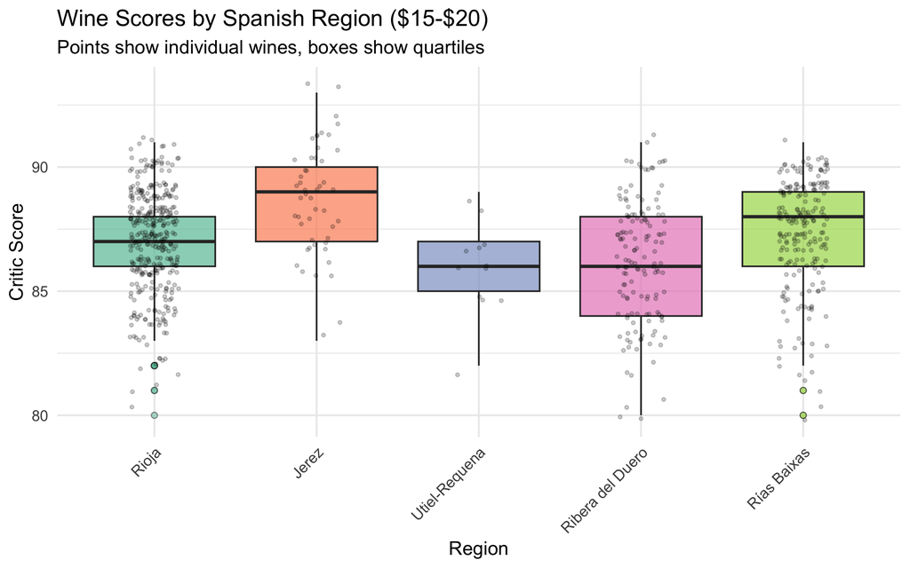

```r
p_box <- ggplot(wine_es, aes(x = region_1, y = points, fill = region_1)) +
  geom_boxplot(alpha = 0.7, outlier.shape = 21, outlier.alpha = 0.5) +
  geom_jitter(width = 0.15, alpha = 0.2, size = 0.8) +
  scale_fill_brewer(palette = "Set2") +
  labs(x = "Region",
       y = "Critic Score",
       title = paste0("Wine Scores by Spanish Region ",
                      "(", if(params$budget_mode) "$15-$20" else "All Prices", ")"),
       subtitle = "Points show individual wines, boxes show quartiles") +
  theme(legend.position = "none",
        axis.text.x = element_text(angle = 45, hjust = 1))

print(p_box)
```

```r
# Save plot
ggsave(filename = file.path("figs",
                            paste0("boxplot_",
                                   if(params$budget_mode) "budget" else "all",
                                   ".png")),
       plot = p_box, width = 8, height = 5, dpi = 160)
```

### Score Distributions

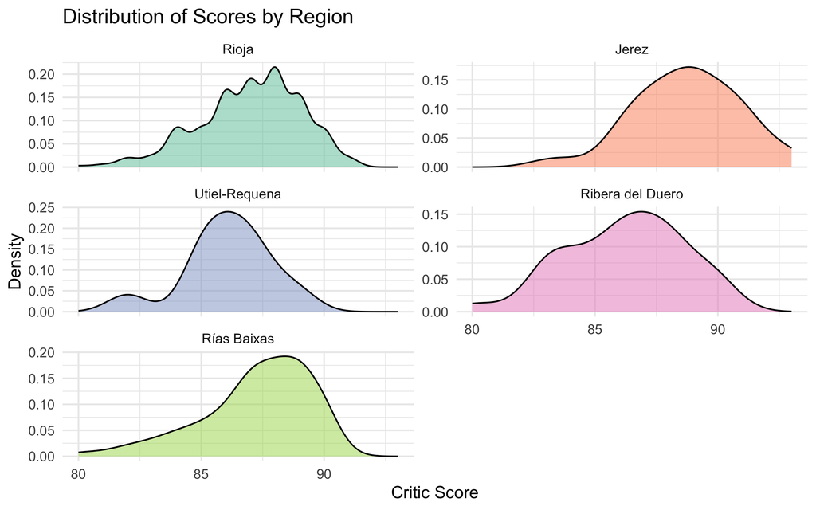

```r
p_density <- wine_es %>%
  ggplot(aes(x = points, fill = region_1)) +
  geom_density(alpha = 0.5) +
  facet_wrap(~ region_1, ncol = 2, scales = "free_y") +
  scale_fill_brewer(palette = "Set2") +
  labs(x = "Critic Score",
       y = "Density",
       title = "Distribution of Scores by Region") +
  theme(legend.position = "none")

print(p_density)
```

## 4. Bayesian Hierarchical Model

### Model Specification

We model critic scores using a hierarchical structure:

$$\begin{aligned}
y_{ij} \mid \theta_j, \sigma^2 &\sim \mathcal{N}(\theta_j, \sigma^2)
\quad \text{(scores within region)} \\
\theta_j \mid \mu, \tau^2 &\sim \mathcal{N}(\mu, \tau^2) \quad
\text{(region means)} \\
\end{aligned}$$

With priors: - $\mu \sim \mathcal{N}(88.5, 1000)$ (grand mean) - $\sigma^2 \sim \text{Inv-Gamma}(0.5, 5)$ (within-region variance) - $\tau^2 \sim \text{Inv-Gamma}(0.5, 5)$ (between-region variance)

### Fit Model via Gibbs Sampling

```r
# Check that we have data
if (!exists("Y") || length(Y) == 0) {
  stop("No data available for model fitting. Check data preparation step.")
}

cat("Number of regions:", length(Y), "\n")
```

```
## Number of regions: 5
```

```r
cat("Sample sizes:", sapply(Y, length), "\n")
```

```
## Sample sizes: 112 39 12 83 209
```

```r
# Set priors (weakly informative)
priors <- list(
  mu0 = 88.5,   # Prior mean (typical wine score)
  g0sq = 1000,  # Prior variance on mu (diffuse)
  nu0 = 1,      # Prior df for sigma2
  s0 = 10,      # Prior scale for sigma2
  eta0 = 1,     # Prior df for tau2
  t0 = 10       # Prior scale for tau2
)

# Run Gibbs sampler
cat("Running Gibbs sampler with", 5000, "iterations...\n")
```

```
## Running Gibbs sampler with 5000 iterations...
```

```r
fit <- gibbs_hier_normal(Y, priors = priors, S = 5000, seed = params$seed)

THETA <- fit$THETA
MST   <- fit$MST
post  <- fit$post

cat("Sampling complete.\n")
```

```
## Sampling complete.
```

```r
cat("MCMC dimensions: ", dim(MST), "\n")
```

```
## MCMC dimensions:  5000 3
```

## 5. MCMC Diagnostics

### Effective Sample Sizes

```r
# Note: Effective sample size calculation
if (exists("MST") && !is.null(MST) && nrow(MST) > 0) {
  cat("Total MCMC iterations:", nrow(MST), "\n")
  cat("Parameters tracked: μ, σ², τ²\n")
  cat("Note: For detailed ESS, run effectiveSize(MST) manually after knitting.\n")
} else {
  cat("MCMC not yet run or no data available.\n")
}
```

```
## Total MCMC iterations: 5000
## Parameters tracked: μ, σ², τ²
## Note: For detailed ESS, run effectiveSize(MST) manually after knitting.
```

### Trace Plots

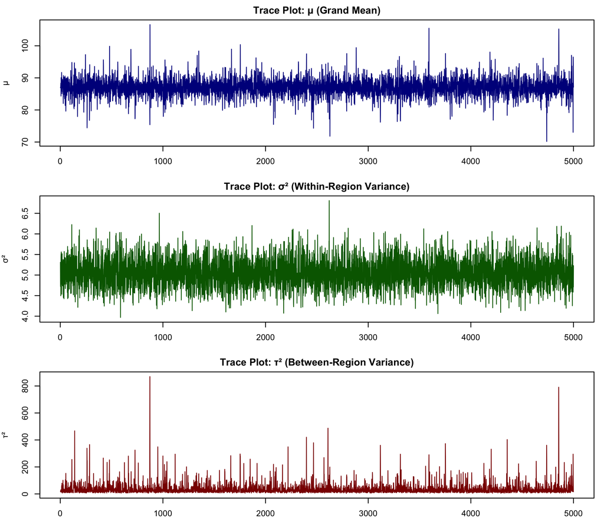

```r
if (exists("MST") && !is.null(MST) && nrow(MST) > 0) {
  par(mfrow = c(3, 1), mar = c(3, 4, 2, 1))

  # Mu
  plot(MST[, "mu"], type = "l", col = "darkblue",
       main = "Trace Plot: μ (Grand Mean)",
       ylab = "μ", xlab = "Iteration")

  # Sigma2
  plot(MST[, "sigma2"], type = "l", col = "darkgreen",
       main = "Trace Plot: σ² (Within-Region Variance)",
       ylab = "σ²", xlab = "Iteration")

  # Tau2
  plot(MST[, "tau2"], type = "l", col = "darkred",
       main = "Trace Plot: τ² (Between-Region Variance)",
       ylab = "τ²", xlab = "Iteration")

  par(mfrow = c(1, 1))
} else {
  cat("MCMC data not available for trace plots.\n")
}
```

### Autocorrelation Functions

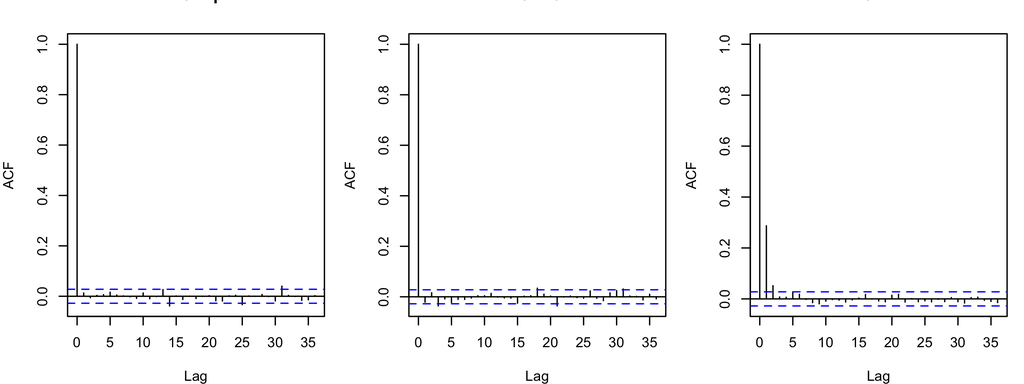

```r
if (exists("MST") && !is.null(MST) && nrow(MST) > 0) {
  # Save ACF plots
  par(mfrow = c(1, 3), mar = c(4, 4, 2, 1))

  acf(MST[, "mu"], main = "ACF: μ")
  acf(MST[, "sigma2"], main = "ACF: σ²")
  acf(MST[, "tau2"], main = "ACF: τ²")

  par(mfrow = c(1, 1))
} else {
  cat("MCMC data not available for ACF plots.\n")
}
```

## 6. Posterior Inference

### Region-Specific Means

```r
# Calculate posterior summaries
post_theta <- apply(THETA, 2, mean)
ci_theta   <- apply(THETA, 2, quantile, probs = c(0.025, 0.5, 0.975)) %>%
  t() %>%
  as.data.frame()

ci_theta$region <- rownames(ci_theta)
names(ci_theta) <- c("Lower95", "Median", "Upper95", "Region")

# Create summary table
theta_tbl <- ci_theta %>%
  dplyr::select(Region, Lower95, Median, Upper95) %>%
  mutate(across(where(is.numeric), ~round(., 2))) %>%
  arrange(desc(Median))

knitr::kable(theta_tbl,
             caption = "Posterior Estimates of Region Means (95% Credible Intervals)")
```

Posterior Estimates of Region Means (95% Credible Intervals)

|  | Region | Lower95 | Median | Upper95 |
| --- | --- | --- | --- | --- |
| Jerez | Jerez | 87.73 | 88.42 | 89.13 |
| Rías Baixas | Rías Baixas | 86.97 | 87.27 | 87.58 |
| Rioja | Rioja | 86.71 | 87.14 | 87.54 |
| Ribera del Duero | Ribera del Duero | 85.90 | 86.36 | 86.86 |
| Utiel-Requena | Utiel-Requena | 84.82 | 86.10 | 87.42 |

```r
# Save to CSV
write_csv(theta_tbl,
          file.path("outputs",
                    paste0("posterior_region_means_",
                           if(params$budget_mode) "budget" else "all",
                           ".csv")))
```

### Forest Plot

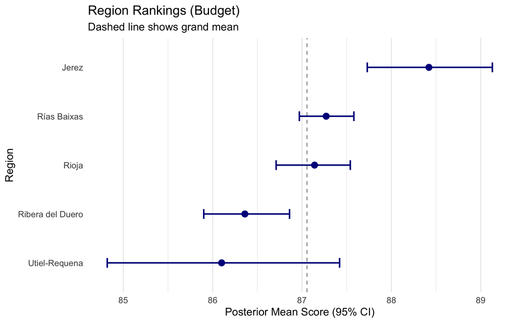

```r
p_forest <- ggplot(theta_tbl, aes(x = reorder(Region, Median), y = Median)) +
  geom_point(size = 3, color = "darkblue") +
  geom_errorbar(aes(ymin = Lower95, ymax = Upper95),
                width = 0.2, color = "darkblue", size = 0.8) +
  geom_hline(yintercept = mean(MST[, "mu"]),
             linetype = "dashed", alpha = 0.5) +
  coord_flip() +
  labs(x = "Region",
       y = "Posterior Mean Score (95% CI)",
       title = paste0("Region Rankings ",
                      "(", if(params$budget_mode) "Budget" else "All Prices", ")"),
       subtitle = "Dashed line shows grand mean") +
  theme(panel.grid.major.y = element_blank())

print(p_forest)
```

```r
# Save plot
ggsave(file.path("figs",
                 paste0("forest_",
                        if(params$budget_mode) "budget" else "all",
                        ".png")),
       p_forest, width = 7, height = 5, dpi = 160)
```

### Global Parameters

```r
# Posterior summaries for global parameters
global_summary <- data.frame(
  Parameter = c("μ (Grand Mean)",
                "σ² (Within-Region Var)",
                "τ² (Between-Region Var)"),
  Mean = c(mean(MST[, "mu"]),
           mean(MST[, "sigma2"]),
           mean(MST[, "tau2"])),
  `CI_2.5%` = c(quantile(MST[, "mu"], 0.025),
                quantile(MST[, "sigma2"], 0.025),
                quantile(MST[, "tau2"], 0.025)),
  `CI_97.5%` = c(quantile(MST[, "mu"], 0.975),
                 quantile(MST[, "sigma2"], 0.975),
                 quantile(MST[, "tau2"], 0.975))
) %>%
  mutate(across(where(is.numeric), ~round(., 2)))

knitr::kable(global_summary,
             caption = "Posterior Estimates of Global Parameters")
```

Posterior Estimates of Global Parameters

| Parameter | Mean | CI_2.5. | CI_97.5. |
| --- | --- | --- | --- |
| μ (Grand Mean) | 87.06 | 81.77 | 92.36 |
| σ² (Within-Region Var) | 5.05 | 4.42 | 5.76 |
| τ² (Between-Region Var) | 35.14 | 8.26 | 134.56 |

## 7. Variance Decomposition

### Between vs. Within Region Variation

```r
# Calculate R = tau² / (tau² + sigma²)
R_post <- post$tau2 / (post$tau2 + post$sigma2)
R_summary <- quantile(R_post, c(0.025, 0.5, 0.975))

cat("Proportion of variance due to region (R):\n")
```

```
## Proportion of variance due to region (R):
```

```r
cat(sprintf("  Median: %.1f%%\n", 100 * R_summary[2]))
```

```
##   Median: 82.4%
```

```r
cat(sprintf("  95%% CI: [%.1f%%, %.1f%%]\n",
            100 * R_summary[1], 100 * R_summary[3]))
```

```
##   95% CI: [61.7%, 96.3%]
```

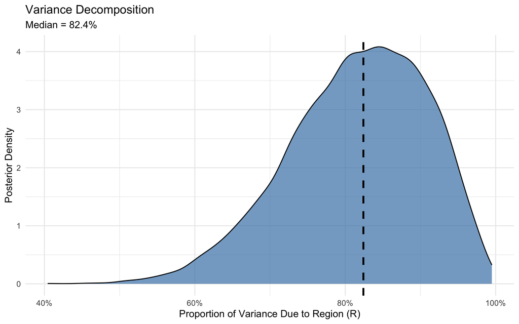

```r
# Plot density
p_R <- data.frame(R = R_post) %>%
  ggplot(aes(x = R)) +
  geom_density(fill = "steelblue", alpha = 0.7) +
  geom_vline(xintercept = R_summary[2],
             linetype = "dashed", size = 1) +
  scale_x_continuous(labels = scales::percent) +
  labs(x = "Proportion of Variance Due to Region (R)",
       y = "Posterior Density",
       title = "Variance Decomposition",
       subtitle = paste0("Median = ", round(100 * R_summary[2], 1), "%")) +
  theme_minimal()

print(p_R)
```

```r
# Save plot
ggsave(file.path("figs",
                 paste0("R_density_",
                        if(params$budget_mode) "budget" else "all",
                        ".png")),
       p_R, width = 6, height = 4, dpi = 160)
```

## 8. Key Findings

### Main Results

1. **Top Region**: **Jerez** has the highest posterior mean score (88.42)
2. **Regional Differences**: Approximately **82.4%** of score variation is attributable to region (vs. individual bottle variation)
3. **Price Context**: This analysis uses budget wines ($15-$20)

### Statistical Interpretation

- The 95% credible intervals show which regions are statistically distinguishable
- Overlapping intervals suggest regions with similar quality distributions
- The relatively high between-region variance (82.4%) indicates substantial regional effects

### To Reproduce This Analysis

1. Install required packages:

```r
install.packages(c("dplyr", "ggplot2", "readr",
                   "tidyr", "purrr", "coda", "knitr"))
```

2. Run with different parameters:

```r
# Budget mode
rmarkdown::render('spanish-wines-bayesian.Rmd',
                  params = list(budget_mode = TRUE, seed = 1))

# All prices
rmarkdown::render('spanish-wines-bayesian.Rmd',
                  params = list(budget_mode = FALSE, seed = 1))
```

*Analysis completed on 2025-08-20*